# Simple model to predict hand-writing using R neuralnet library

Kean Loon Lee

Oct 10th, 2015

Predict NIST hand-writing data using R neural network package: neuralnet

```r
library(neuralnet) # for neural network
```

```r
library(ggplot2) # for plotting
library(Rmisc)
library(reshape2) # for data frame manipulation
```

Read in test and train data provided by Kaggle

```r
test <- read.csv("test.csv")
train <- read.csv("train.csv")
```

Define a function that randomly split a dataframe into ratio:(1-ratio) for training set and cross validation set

```r
splitdf <- function(dataframe, ratio, seed=NULL) {
  if (!is.null(seed)) set.seed(seed)
  n <- nrow(dataframe)
  trainindex <- sample(1:n, n*ratio)
  trainset <- dataframe[trainindex, ] # training set
  cvset <- dataframe[-trainindex, ] # cross-validation set
  list(trainset=trainset,cvset=cvset)
}
```

Split our training data into 80:20 training and cross validation set

```r
df <- splitdf(train,0.8,81)
trainset <- df$trainset
cvset <- df$cvset
rm(df) # no use with df now
```

Visualise the first 9 rows of cross-validation set.

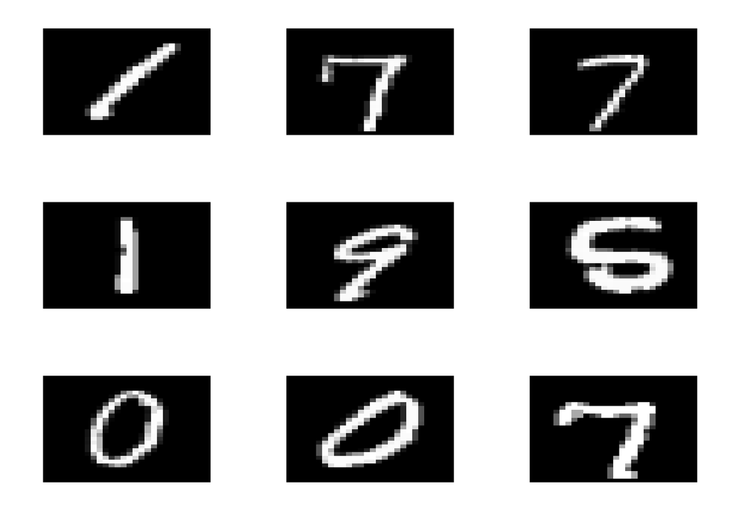

```r
plots <- list() # new empty list
for (i in 1:9){
  z1 <- melt(cvset[i,1:785],id.vars = "label")
  y <- rep(28:1,each=28)
  x <- rep(1:28,times=28)
  z <- cbind(x,y,z1)

  # add each plot to the plot list
  plots[[i]] <- ggplot(z) + geom_raster(aes(x=x, y=y, fill=value)) +
                guides(fill=FALSE) + # legend is redundant
                scale_x_continuous(limits=c(1, 28)) +
                scale_y_continuous(limits=c(1, 28)) +
                scale_fill_continuous(low="#000000", high="#ffffff") +
    # remove the background,ticks,labels, etc to make the plots look nicer
    theme(axis.line=element_blank(),axis.text.x=element_blank(),
          axis.text.y=element_blank(),axis.ticks=element_blank(),
          axis.title.x=element_blank(),
          axis.title.y=element_blank(),legend.position="none",
          panel.background=element_blank(),panel.border=element_blank(),panel.grid.major=element_blank(),
          panel.grid.minor=element_blank(),plot.background=element_blank())
}
rm(x,y,z,z1) # remove redundant variables
multiplot(plotlist = plots, cols = 3)
```

Check if the labels agree with the plotted images.

```r
cvset[1:9,1]
```

```
## [1] 1 1 0 7 9 0 7 5 7
```

Convert label 0 into 10 for easier manupulation later.

```r
trainset[trainset$label==0,"label"] = 10
```

Normalise the data set (scale the input to manageable range for neuralnet library). This step is actually very important. I have spent several days to figure out why the neuralnet library does not produce results until I normalised the input grey scale values.

```r
trainset[,2:785] <- trainset[,2:785]/255.
cvset[,2:785] <- cvset[,2:785]/255.
test <- test/255.
```

Define a function to convert digit label into logical matrix

```r
convertLabel <- function(w){
                  a <-rep(0,10)
                  a[w] <- 1
                  a
}
```

Add the converted logical array to the train data

```r
m <- as.data.frame(t(sapply(trainset$label,convertLabel)))
names(m) <- paste('d',1:10,sep='')
trainset <- cbind(m,trainset)
rm(m)
```

Train the neural network. We are going to have 100 nodes with a single hidden layer. Threshold is a numeric value specifying the threshold for the partial derivatives of the error function as stopping criteria. formula for the neural network

```r
netformula <- paste(paste(paste('d',1:10,sep=''),collapse='+'),' ~ ',
                    paste(paste('pixel',0:783,sep=''), collapse='+'), sep='')
```

Choose the number of training examples to plot learning curve

```r
ntrain = 1000
```

Train the network

```r
net <- neuralnet(netformula,trainset[1:ntrain,], hidden=c(100),err.fct="ce",
                 linear.output = FALSE,threshold=0.01,lifesign='minimal')
```

```
## hidden: 100    thresh: 0.01    rep: 1/1    steps:      53    error: 0.13689  time: 11.13 secs
```

Output tells us the train error (cross-entropy) multiplies the number of test examples, and the time taken to train the neural network. Compute predictions on our cross-validatation set

```r
results <- compute(net,cvset[,2:785])
myPredict <- apply(results$net.result,1,which.max)
```

Accuracy of our prediction

```r
myPredict[myPredict==10] <- 0 # convert 10 back into 0
acc_cv <- sum(myPredict == cvset$label)/nrow(cvset)
acc_cv
```

```
## [1] 0.8647619048
```

We can repeat the neural network for different number of training examples and number of nodes in the hidden layer. However, we always get 0 error in using the trained parameters on the training set. I believe that overfitting is present here. A remedy would be to implement regularisation, which is not available in this R package.

Summary of the number of nodes and layers that I have tried.

```r
combine.res <- read.csv("neuralnetPrediction.csv")
```

Cross-validation accuracy

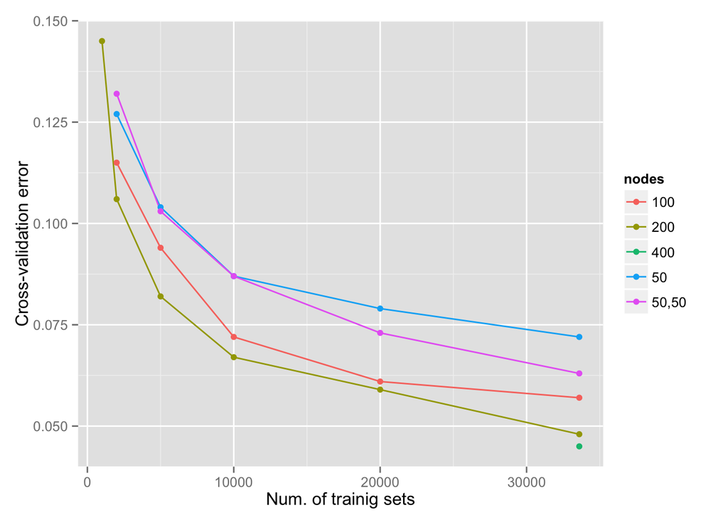

```r
p1 <-  ggplot(combine.res,aes(x=num_train_ex,y=1.-prediction_accuracy,colour=nodes)) +
  geom_line(stat="identity") + geom_point(fill="white") +
  labs(x="Num. of trainig sets") + labs(y="Cross-validation error")
print(p1)
```

Computing time on a single processor (2.9GHz Intel Core i7)

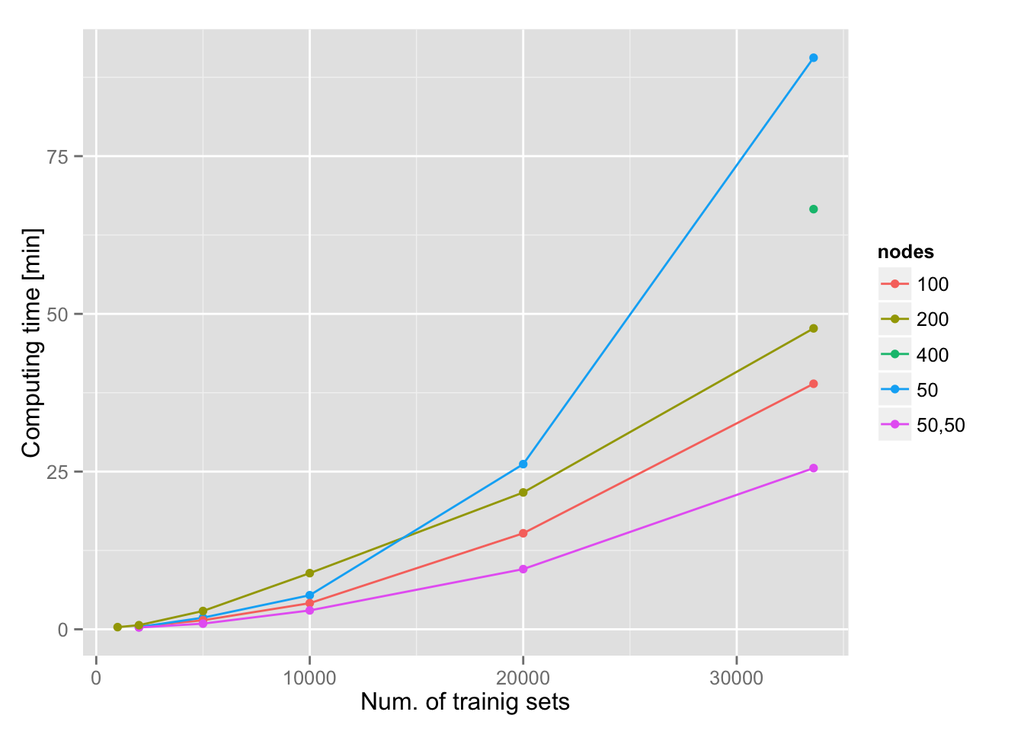

```r
p2 <-  ggplot(combine.res,aes(x=num_train_ex,y=time,colour=nodes)) +
  geom_line(stat="identity") + geom_point(fill="white") +
  labs(x="Num. of trainig sets") + labs(y="Computing time [min]")
print(p2)
```

Finally, compute predictions on Kaggle test set. Kaggle returns 0.958 accuracy for 400 nodes, single-hidden-layer, 33600 training examples. This is close to the cross-validation result (0.955), as expected.

```r
results <- compute(net,test)
myPredict <- apply(results$net.result,1,which.max)
myPredict[myPredict==10] <- 0 # convert 10 back into 0
kaggle_data <-data.frame(ImageId=1:nrow(test),Label=myPredict)
write.csv(kaggle_data,file="kaggle_result.csv",row.names=FALSE)
```